← AN05B023b/c scenes

# AN05B023b/c cut at b’s reach

## The cut

AN05B023b is cut off in the brain. `05_an05b023bc.Rmd` therefore scores every partner beyond that point as a b-side zero, which is a fact about the reconstruction and not about the neuron.

This page truncates AN05B023c at the plane where AN05B023b ends, and runs the same plots on what is left. The cut is a single plane on `y`, the axis the brain and the VNC separate on: brain synapses run y 17.8k-46.9k, VNC synapses y 46.1k-67.2k, so smaller y is further into the brain.

```r
options(rgl.useNULL = TRUE)   # must precede any library that pulls rgl in (nat)

suppressMessages({
  library(neuprintr); library(malecns); library(nat)
  library(coconatfly); library(coconat)
  options(malecns.dataset = "male-cns:v1.0")   # malecns helpers ignore MCNS_DATASET
  library(dplyr); library(tibble)
  library(ggplot2); library(ggrepel); library(scales); library(patchwork)
})

R_DIR <- "/Users/fkampf/Documents/pheromone.paper/analyses/an_investigation/R"

Sys.setenv(AN_CASE = "an05b023bc")
source(file.path(R_DIR, "_paths.R"))
source(file.path(R_DIR, "_an_pair.R"))
neuprint_login(server = MCNS_SERVER, dataset = MCNS_DATASET)

PAIR <- TARGET_TYPES
PAIR
```

```
## [1] "AN05B023b" "AN05B023c"
```

```r
load_once <- function(name, expr, envir = .GlobalEnv) {
  # eval() here evaluates a quote()d expression written literally in this file -
  # a lazy-evaluation idiom for "only fetch if not already cached", not a parser
  # of external input.
  if (!exists(name, envir = envir, inherits = FALSE)) {
    assign(name, eval(expr), envir = envir)
  }
  get(name, envir = envir)
}

mba <- load_once("mba", quote(mcns_body_annotations()))

contact_pool <- sensory_pool(mba)
```

Every synapse on the four bodies, with coordinates, the same way `01_fetch_input_synapses.R` gets them — `prepost == 1` means the target body is POST, so those rows are its inputs and `prepost == 0` are its outputs.

`y_min` per body is how far each one reaches. AN05B023b R never enters the brain at all; AN05B023b L is the one that gets furthest, and where it stops is the cut.

```r
pair_bodies <- mba |>
  filter(type %in% PAIR) |>
  select(bodyid, type, soma_side)

syn <- load_once("syn_bc", quote(
  neuprint_get_synapses(pair_bodies$bodyid) |>
    left_join(pair_bodies, by = "bodyid")
))

syn |>
  summarise(synapses = n(), y_min = min(y), y_um = round(min(y) * 8 / 1000, 1),
            .by = c(type, soma_side)) |>
  arrange(type, soma_side)
```

| type | soma_side | synapses | y_min | y_um |
| --- | --- | --- | --- | --- |
| AN05B023b | L | 16862 | 35076 | 280.6 |
| AN05B023b | R | 16545 | 51028 | 408.2 |
| AN05B023c | L | 19103 | 19649 | 157.2 |
| AN05B023c | R | 19333 | 17803 | 142.4 |

`CUT_Y` is the reach of whichever type stops first, pooled over its bodies, and everything anterior to it is dropped from both types. Taking the max of the per-type minima keeps the page honest if the roles ever swap.

```r
CUT_Y <- max(summarise(syn, y_min = min(y), .by = type)$y_min)

cut_syn <- syn |> filter(y >= CUT_Y)

c(cut_y = CUT_Y, cut_um = round(vox_to_um(CUT_Y), 1))
```

```
##   cut_y  cut_um
## 35076.0   280.6
```

What the cut costs each type. b keeps everything by construction; the number to read is how much of c goes.

```r
syn |>
  mutate(keep = y >= CUT_Y,
         side = if_else(prepost == 1, "input", "output")) |>
  summarise(whole = n(), kept = sum(keep), .by = c(type, side)) |>
  mutate(frac_kept = round(kept / whole, 3)) |>
  arrange(side, type)
```

| type | side | whole | kept | frac_kept |
| --- | --- | --- | --- | --- |
| AN05B023b | input | 17326 | 17326 | 1.000 |
| AN05B023c | input | 10924 | 10653 | 0.975 |
| AN05B023b | output | 16081 | 16081 | 1.000 |
| AN05B023c | output | 27512 | 11763 | 0.428 |

## The cut, drawn

Every synapse on the four bodies, projected sagittally: `z` runs posterior, `y` runs ventral, both in µm, and the dashed line is `CUT_Y`. Faded points are the ones the cut drops. The histogram underneath is the same data collapsed onto the cut axis, which is where the two distributions can be compared directly.

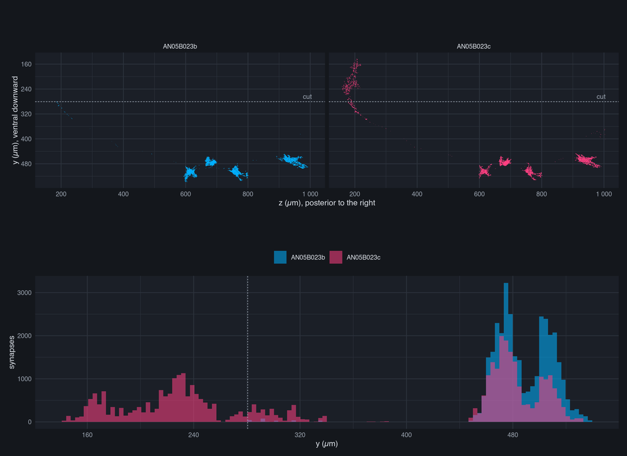

```r
type_cols <- setNames(unname(PAIR_COLS), PAIR)

syn_cut <- syn |> mutate(kept = y >= CUT_Y)

p_sag <- ggplot(syn_cut, aes(z, y)) +
  geom_point(aes(colour = type, alpha = kept), size = 0.25, stroke = 0) +
  geom_hline(yintercept = CUT_Y, linewidth = 0.4, linetype = "22",
             colour = DARK_DIM) +
  annotate("text", x = max(syn_cut$z), y = CUT_Y, label = " cut",
           hjust = 1, vjust = -0.6, size = 3, colour = DARK_DIM) +
  facet_wrap(~ type, nrow = 1) +
  scale_colour_manual(values = type_cols, guide = "none") +
  scale_alpha_manual(values = c(`TRUE` = 0.5, `FALSE` = 0.08), guide = "none") +
  scale_y_reverse(labels = label_number(scale = 8 / 1000)) +
  scale_x_continuous(labels = label_number(scale = 8 / 1000)) +
  coord_fixed() +
  labs(x = "z (µm), posterior to the right", y = "y (µm), ventral downward") +
  theme_site(base_size = 10)

p_hist <- ggplot(syn_cut, aes(y, fill = type)) +
  geom_histogram(bins = 120, position = "identity", alpha = 0.55) +
  geom_vline(xintercept = CUT_Y, linewidth = 0.4, linetype = "22",
             colour = DARK_DIM) +
  scale_fill_manual(values = type_cols, name = NULL) +
  scale_x_continuous(labels = label_number(scale = 8 / 1000)) +
  labs(x = "y (µm)", y = "synapses") +
  theme_site(base_size = 10) +
  theme(legend.position = "top")

p_sag / p_hist + plot_layout(heights = c(1.3, 1))
```

What the picture shows, and it matters for how much this page can claim: b is not a clean stop. Its L body does send a thin line of synapses forward into the brain, reaching z = 23,117 against c’s 19,872 — nearly as deep — but it puts only 244 synapses there against roughly 9,500 per c body. The missing thing is the arbor, not the distance.

So the cut axis is a choice. On `y` it removes 57% of c’s output; cutting on `z` at b’s deepest point instead would remove only 26%, because b’s stub reaches almost as far anteriorly as c does. This page cuts on `y`, which is the axis the two distributions actually separate on in the histogram above, and the more conservative of the two.

## Edges within the cut

Counted from the synapses themselves rather than from `mcns_connection_table()`, because the restriction is a plane and not an ROI. One row per synapse, so `total` is the same edge weight the other pages use.

```r
cut_edges <- function(tp, dir, sensory = FALSE) {
  cut_syn |>
    filter(type == tp, prepost == if (dir == "o") 0 else 1) |>
    left_join(mba |> select(partner = bodyid, partner_type = type),
              by = "partner") |>
    filter(!is.na(partner_type), nzchar(partner_type)) |>
    filter(if (sensory) partner %in% contact_pool
           else       !(partner %in% contact_pool)) |>
    summarise(total = n(), n_partner = n_distinct(partner), .by = partner_type) |>
    rename(type = partner_type) |>
    arrange(desc(total))
}
```

## Downstream output, cut

```r
l_output <- cut_edges(PAIR[1], "o")
r_output <- cut_edges(PAIR[2], "o")

setNames(c(sum(l_output$total), sum(r_output$total)), PAIR)
```

```
## AN05B023b AN05B023c
##      4842      4440
```

```r
out_diff <- diff_of(l_output, r_output)

out_diff |> select(type, total_l, total_r, diff, frac_diff)
```

| type | total_l | total_r | diff | frac_diff |
| --- | --- | --- | --- | --- |
| AN05B023c | 464 | 6 | -458 | -9.447682e-02 |
| AN05B023d | 469 | 33 | -436 | -8.942837e-02 |
| ANXXX093 | 434 | 8 | -426 | -8.783058e-02 |
| AN05B102b | 421 | 4 | -417 | -8.604664e-02 |
| DNpe029 | 178 | 0 | -178 | -3.676167e-02 |
| IN00A048 | 171 | 24 | -147 | -2.991058e-02 |
| IN05B011a | 149 | 22 | -127 | -2.581745e-02 |
| AN09B017e | 122 | 0 | -122 | -2.519620e-02 |
| AN05B102c | 119 | 13 | -106 | -2.164869e-02 |
| AN05B097 | 102 | 1 | -101 | -2.084045e-02 |

[output cut: 345 more lines]

```r
MIN_DIFF <- 20   # synapses; a type must differ by at least this to get a bar

shown <- out_diff |> filter(abs(diff) >= MIN_DIFF)
sprintf("%d of %d partner types shown; %d hidden below |diff| = %d",
        nrow(shown), nrow(out_diff), nrow(out_diff) - nrow(shown), MIN_DIFF)
```

```
## [1] "62 of 355 partner types shown; 293 hidden below |diff| = 20"
```

The right-hand panel is the one thing the cut does not reach: a partner’s total input is its whole input, uncut, because cutting it would mean fetching every synapse of every partner. Numerator cut, denominator whole — so read those shares as a lower bound, not as a fraction of the partner’s arbor inside the plane.

```r
bars_out <- bars_downstream(shown, mba)

count(bars_out, grp)
```

| grp | n |
| --- | --- |
| male-specific | 9 |
| potentially male-specific | 1 |
| potentially sexually dimorphic | 2 |
| not annotated | 50 |

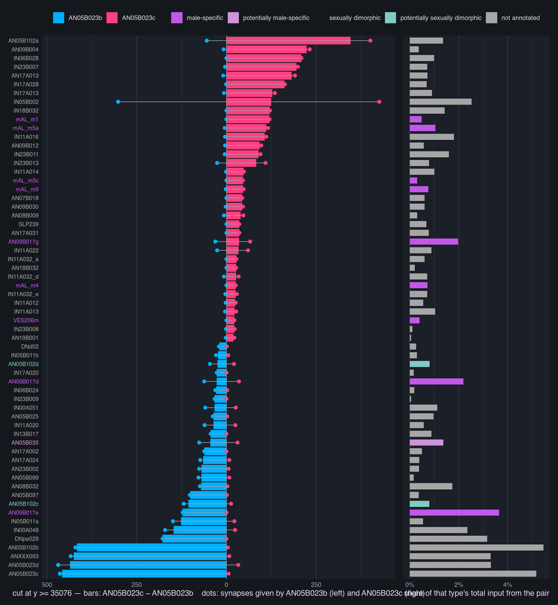

```r
bc_plot(bars_out,
        pair      = PAIR,
        lab_cols  = unname(DIMORPH_COLS[as.character(bars_out$grp)]),
        grp_cols  = DIMORPH_COLS,
        x_lab     = sprintf("cut at y >= %s — bars: %s − %s    dots: synapses given by %s (left) and %s (right)",
                            CUT_Y, PAIR[2], PAIR[1], PAIR[1], PAIR[2]),
        share_lab = "share of that type's total input from the pair")
```

## Output onto dimorphic partners, cut

The same summary as `05_an05b023bc.Rmd`, on the cut edges. This is the version to quote: in 05 the AN05B023c side of it includes the brain arbor AN05B023b does not have, so any excess there is partly a statement about the reconstruction. Here both types are scored on the same volume.

Computed on the whole cut `out_diff` rather than the `MIN_DIFF` subset, and `frac_l` / `frac_r` are shares of that type’s own cut output, so “more” survives one of the two being the bigger neuron inside the plane.

```r
dimorph_out <- dimorph_output(out_diff, mba)

dimorph_out
```

| dimorphism | types | total_l | total_r | frac_l | frac_r |
| --- | --- | --- | --- | --- | --- |
| male-specific | 22 | 244 | 556 | 0.0503923998 | 0.125225225 |
| potentially male-specific | 1 | 76 | 31 | 0.0156959934 | 0.006981982 |
| sexually dimorphic | 3 | 2 | 12 | 0.0004130525 | 0.002702703 |
| potentially sexually dimorphic | 6 | 177 | 41 | 0.0365551425 | 0.009234234 |
| not annotated | 323 | 4343 | 3800 | 0.8969434118 | 0.855855856 |

Total share onto annotated partners, per type:

```r
setNames(colSums(dimorph_out[dimorph_out$dimorphism != "not annotated",
                             c("frac_l", "frac_r")]), PAIR)
```

```
## AN05B023b AN05B023c
## 0.1030566 0.1441441
```

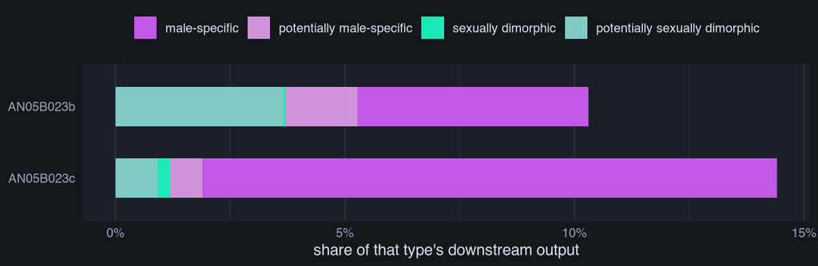

```r
dimorph_output_plot(dimorph_out, PAIR)
```

Read the bar lengths first, the segments only for which class carries it. `not annotated` is the majority class in `mba`, so both bars are short by construction; the comparison is between them, not against 100%.

## Sensory input, cut

The bristle pool sits well behind the plane, so this section should barely move from `05_an05b023bc.Rmd`. Worth showing rather than assuming.

```r
l_input <- cut_edges(PAIR[1], "i", sensory = TRUE)
r_input <- cut_edges(PAIR[2], "i", sensory = TRUE)

in_diff <- diff_of(l_input, r_input)

in_diff |> select(type, total_l, total_r, diff, frac_diff)
```

| type | total_l | total_r | diff | frac_diff |
| --- | --- | --- | --- | --- |
| LgLG1a | 6781 | 250 | -6531 | -0.4881141073 |
| WG4 | 4346 | 185 | -4161 | -0.3089296611 |
| LgLG6 | 342 | 1 | -341 | -0.0264488000 |
| LgLG5 | 156 | 1 | -155 | -0.0119785962 |
| WG1 | 91 | 10 | -81 | -0.0055024700 |
| LgLG7 | 80 | 0 | -80 | -0.0062237436 |
| LgLG2 | 45 | 8 | -37 | -0.0022392251 |
| SNxxxx | 14 | 8 | -6 | 0.0001724755 |
| LgLG8 | 3 | 0 | -3 | -0.0002333904 |
| SNch05 | 16 | 20 | 4 | 0.0019093279 |

[output cut: 4 more lines]

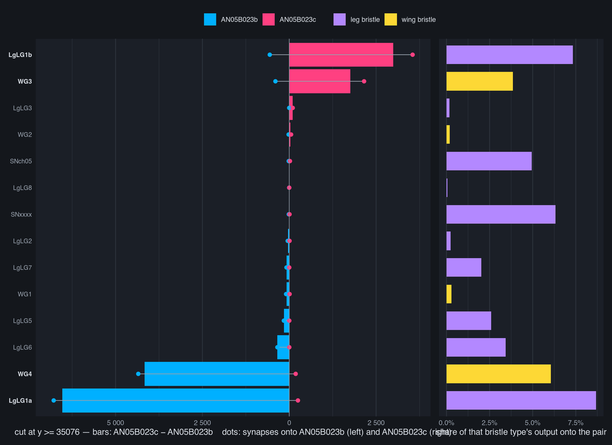

```r
bars_in <- bars_sensory(in_diff, mba, contact_pool)

is_focus <- as.character(bars_in$type) %in% FOCUS

bc_plot(bars_in,
        pair      = PAIR,
        lab_cols  = ifelse(is_focus, DARK_FG, DARK_DIM),
        grp_cols  = SUBCLASS_COLS,
        x_lab     = sprintf("cut at y >= %s — bars: %s − %s    dots: synapses onto %s (left) and %s (right)",
                            CUT_Y, PAIR[2], PAIR[1], PAIR[1], PAIR[2]),
        share_lab = "share of that bristle type's output onto the pair",
        lab_face  = ifelse(is_focus, "bold", "plain"))
```

## What the cut cannot fix

It removes the part of AN05B023c that lies beyond AN05B023b’s end. It does not repair AN05B023b: if that reconstruction also stops short behind the plane, or lost a branch on the way, those synapses are missing here exactly as they are missing in 05, and nothing in the data marks them as missing. Treat every b count as a lower bound.